# p8130_hw5_brm2150

Brooklynn McNeil

2024-12-03

## A.

R data set state.x77 from library(faraway) contains information on 50 states from 1970s collected by US Census Bureau. The goal is to predict ‘life expectancy’ using a combination of remaining variables.The data has the outcome variable `life_exp` and the predictor variables `population`, `income`, `illiteracy`, `murder`, `hs_grad`, `frost`, and `area`. All of the predcitors we have are continuous variables.

```
Load Data
```

```r
data = datasets::state.x77 |>
  as.tibble() |>
  janitor::clean_names()
```

Let’s take a look at the summary of our predictors of interest.

```r
data |>
  summary() |>
  knitr::kable()
```

|  | population | income | illiteracy | life_exp | murder | hs_grad | frost | area |
| --- | --- | --- | --- | --- | --- | --- | --- | --- |
|  | Min. : 365 | Min. :3098 | Min. :0.500 | Min. :67.96 | Min. : 1.400 | Min. :37.80 | Min. : 0.00 | Min. : 1049 |
|  | 1st Qu.: 1080 | 1st Qu.:3993 | 1st Qu.:0.625 | 1st Qu.:70.12 | 1st Qu.: 4.350 | 1st Qu.:48.05 | 1st Qu.: 66.25 | 1st Qu.: 36985 |
|  | Median : 2838 | Median :4519 | Median :0.950 | Median :70.67 | Median : 6.850 | Median :53.25 | Median :114.50 | Median : 54277 |
|  | Mean : 4246 | Mean :4436 | Mean :1.170 | Mean :70.88 | Mean : 7.378 | Mean :53.11 | Mean :104.46 | Mean : 70736 |
|  | 3rd Qu.: 4968 | 3rd Qu.:4814 | 3rd Qu.:1.575 | 3rd Qu.:71.89 | 3rd Qu.:10.675 | 3rd Qu.:59.15 | 3rd Qu.:139.75 | 3rd Qu.: 81162 |
|  | Max. :21198 | Max. :6315 | Max. :2.800 | Max. :73.60 | Max. :15.100 | Max. :67.30 | Max. :188.00 | Max. :566432 |

## B. Exploratory analysis

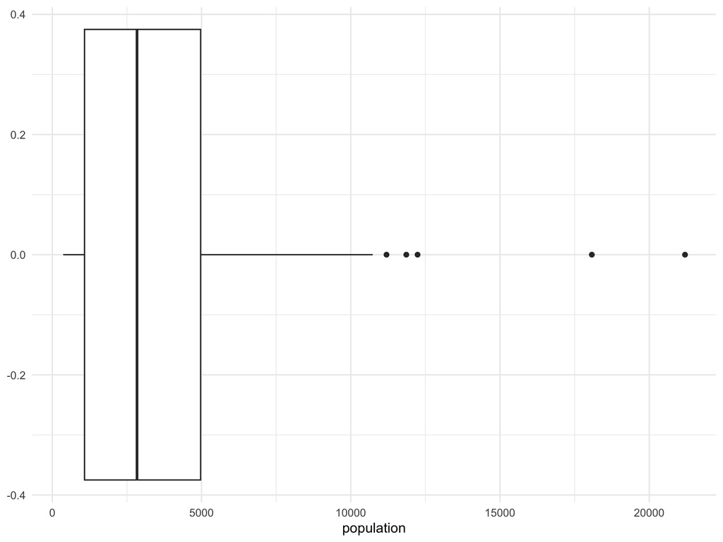

```r
# basic histograms for potentially not normal continuous variables

data |>
  ggplot(aes(x = population)) +
  geom_boxplot()
```

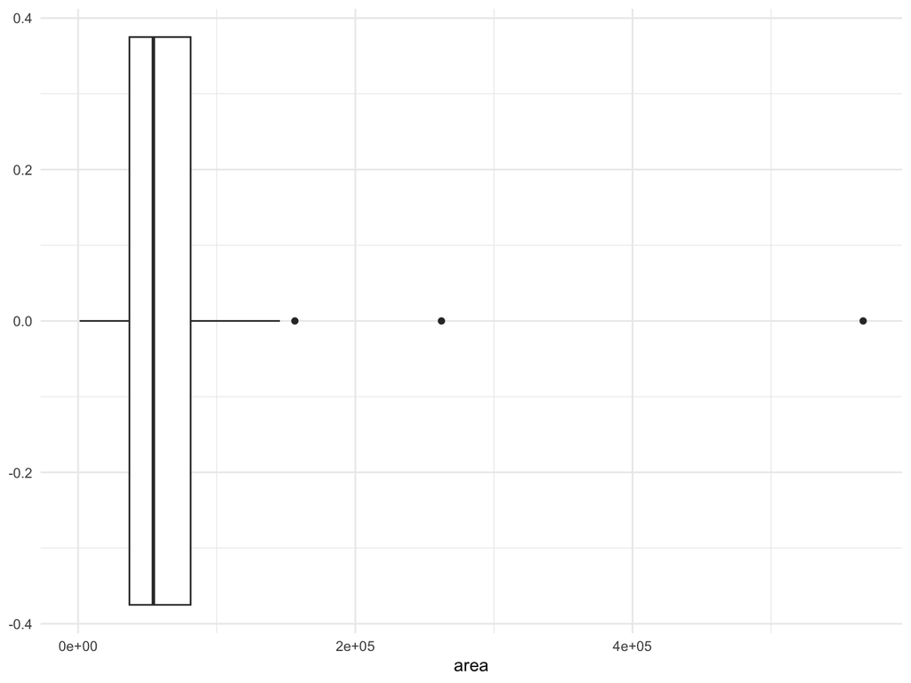

```r
data |>
  ggplot(aes(x = area)) +
  geom_boxplot()
```

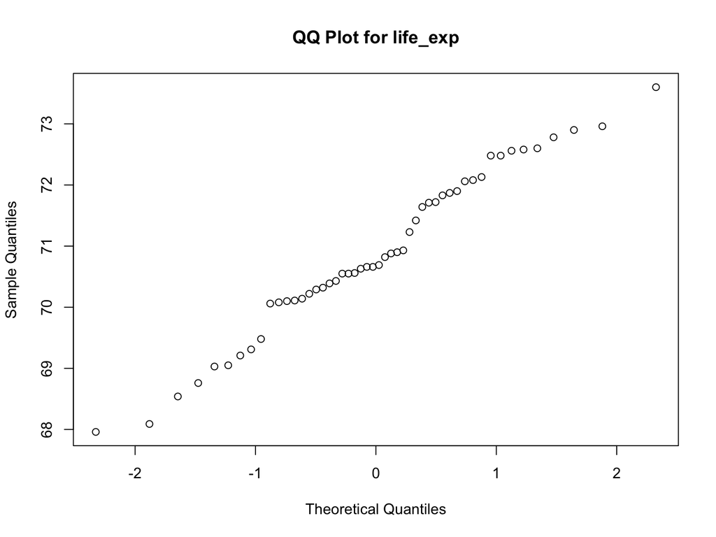

```r
# check for transformations of the outcome
qqnorm(data$life_exp,main = paste("QQ Plot for", "life_exp")) # identitiy
```

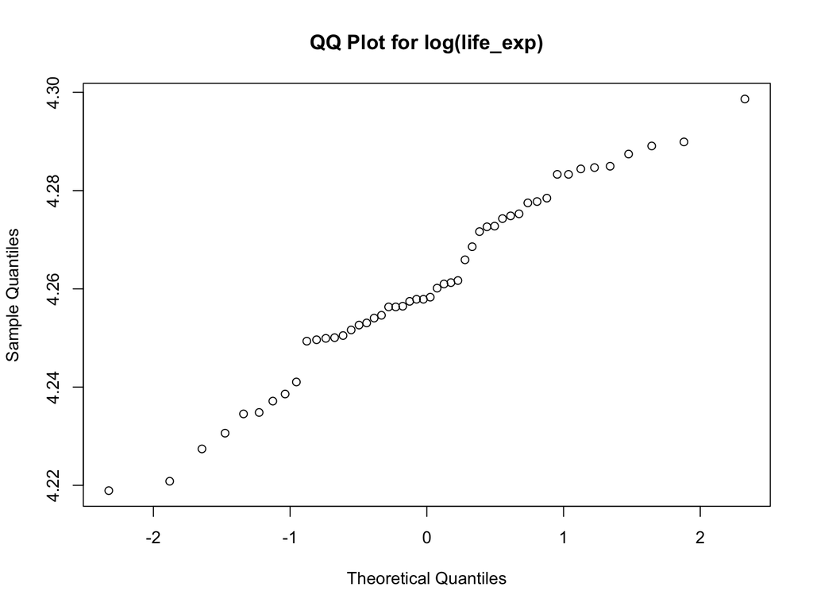

```r
qqnorm(log(data$life_exp), main = paste("QQ Plot for", "log(life_exp)")) # log
```

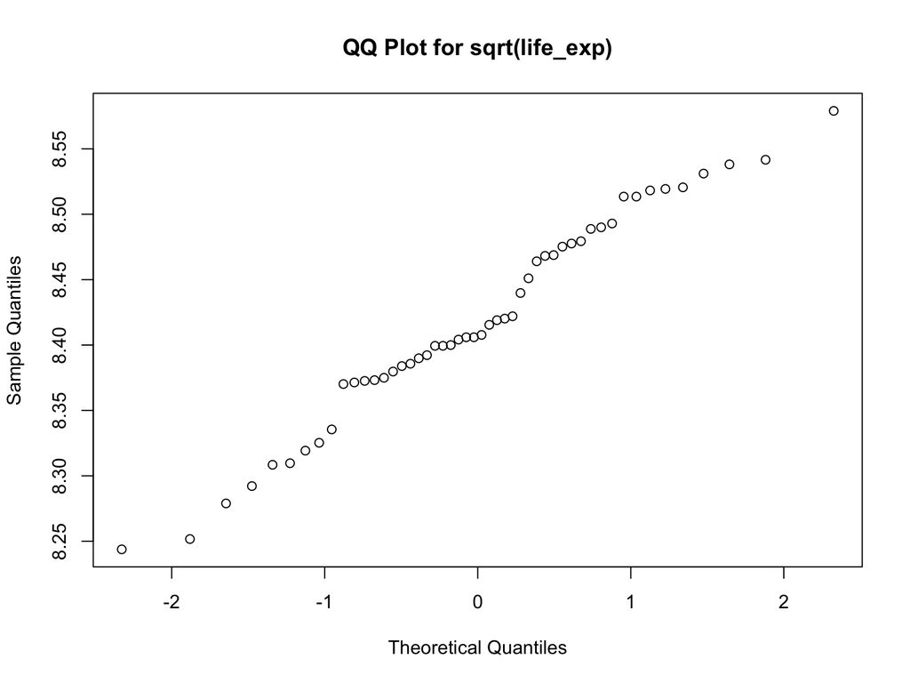

```r
qqnorm(sqrt(data$life_exp), main = paste("QQ Plot for", "sqrt(life_exp)")) # square root
```

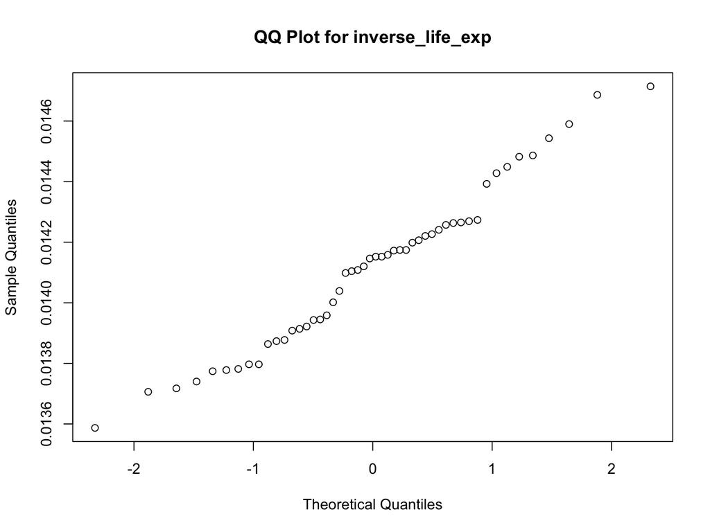

```r
qqnorm(1/(data$life_exp), main = paste("QQ Plot for", "inverse_life_exp")) # inverse
```

Let’s look at correlation of the predictors to make sure there isn’t collinearity that’s obvious at the start.

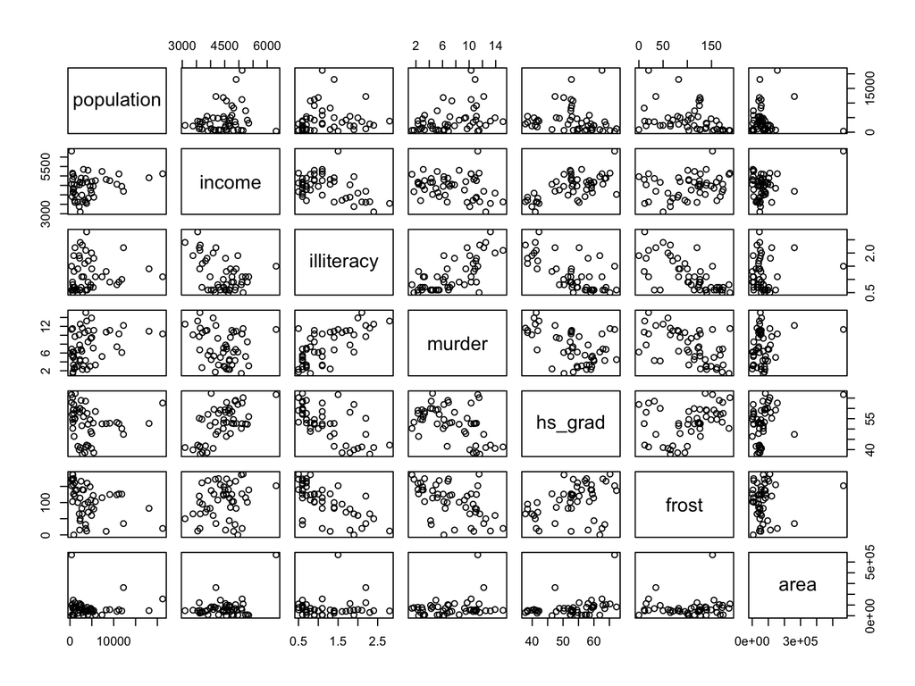

```r
data |>
  select(-life_exp) |>
  pairs()
```

## C.

Use automatic procedures to find a ‘best subset’ of the full model. Backward selection, forward selection, stepwise. It doesn’t look like there is any obvious highly correlated variables, so we don’t need to remove anything at this point. It looks like the forward and backward step approaches led to the same model with final predictors as `population`, `murder`, `hs_grad`, and `frost`.

```r
# backward selection
fit.mult = lm(life_exp ~ log(population) + income + illiteracy + murder + hs_grad + frost + area, data = data)
summary(fit.mult)
```

```
Call:
lm(formula = life_exp ~ log(population) + income + illiteracy +
    murder + hs_grad + frost + area, data = data)

Residuals:
     Min       1Q   Median       3Q      Max
-1.44732 -0.46152  0.04912  0.51562  1.63542

Coefficients:
                  Estimate Std. Error t value Pr(>|t|)
(Intercept)      6.839e+01  2.198e+00  31.109  < 2e-16 ***
log(population)  2.707e-01  1.348e-01   2.009   0.0510 .
income          -4.145e-05  2.424e-04  -0.171   0.8651
illiteracy       9.461e-02  3.685e-01   0.257   0.7986
murder          -2.980e-01  4.524e-02  -6.588 5.67e-08 ***
hs_grad          5.839e-02  2.423e-02   2.410   0.0204 *
frost           -4.645e-03  3.277e-03  -1.418   0.1637
area             2.161e-07  1.666e-06   0.130   0.8974
---
Signif. codes:  0 '***' 0.001 '**' 0.01 '*' 0.05 '.' 0.1 ' ' 1

Residual standard error: 0.7376 on 42 degrees of freedom
Multiple R-squared:  0.7412,    Adjusted R-squared:  0.6981
F-statistic: 17.19 on 7 and 42 DF,  p-value: 1.714e-10
```

```r
fit.back = step(fit.mult, direction = 'backward', trace = FALSE)
summary(fit.back)
```

```
Call:
lm(formula = life_exp ~ log(population) + murder + hs_grad +
    frost, data = data)

Residuals:
     Min       1Q   Median       3Q      Max
-1.41760 -0.43880  0.02539  0.52066  1.63048

Coefficients:
                 Estimate Std. Error t value Pr(>|t|)
(Intercept)     68.720810   1.416828  48.503  < 2e-16 ***
log(population)  0.246836   0.112539   2.193 0.033491 *
murder          -0.290016   0.035440  -8.183 1.87e-10 ***
hs_grad          0.054550   0.014758   3.696 0.000591 ***
frost           -0.005174   0.002482  -2.085 0.042779 *
---
Signif. codes:  0 '***' 0.001 '**' 0.01 '*' 0.05 '.' 0.1 ' ' 1

Residual standard error: 0.7137 on 45 degrees of freedom
Multiple R-squared:  0.7404,    Adjusted R-squared:  0.7173
F-statistic: 32.09 on 4 and 45 DF,  p-value: 1.17e-12
```

```r
# forward selection

intercept_only = lm (life_exp ~ 1, data = data, trace = FALSE)
fit.forward = step(intercept_only, direction = "forward", scope = formula(fit.mult), trace = FALSE)
summary(fit.forward)
```

```
Call:
lm(formula = life_exp ~ murder + hs_grad + log(population) +
    frost, data = data, trace = FALSE)

Residuals:
     Min       1Q   Median       3Q      Max
-1.41760 -0.43880  0.02539  0.52066  1.63048

Coefficients:
                 Estimate Std. Error t value Pr(>|t|)
(Intercept)     68.720810   1.416828  48.503  < 2e-16 ***
murder          -0.290016   0.035440  -8.183 1.87e-10 ***
hs_grad          0.054550   0.014758   3.696 0.000591 ***
log(population)  0.246836   0.112539   2.193 0.033491 *
frost           -0.005174   0.002482  -2.085 0.042779 *
---
Signif. codes:  0 '***' 0.001 '**' 0.01 '*' 0.05 '.' 0.1 ' ' 1

Residual standard error: 0.7137 on 45 degrees of freedom
Multiple R-squared:  0.7404,    Adjusted R-squared:  0.7173
F-statistic: 32.09 on 4 and 45 DF,  p-value: 1.17e-12
```

```r
# stepwise
```

The `log(population)` and `frost` variables are close call variables. So, let’s remove therm and refit the model. Removing the variables reduced the Adjusted R-squared value, therefore reducing the performance of the model. So we will keep them

```r
fit.3 = lm(life_exp ~ murder + hs_grad,
    data = data, trace = FALSE)
summary(fit.3)
```

```
Call:
lm(formula = life_exp ~ murder + hs_grad, data = data, trace = FALSE)

Residuals:
     Min       1Q   Median       3Q      Max
-1.66758 -0.41801  0.05602  0.55913  2.05625

Coefficients:
            Estimate Std. Error t value Pr(>|t|)
(Intercept) 70.29708    1.01567  69.213  < 2e-16 ***
murder      -0.23709    0.03529  -6.719 2.18e-08 ***
hs_grad      0.04389    0.01613   2.721  0.00909 **
---
Signif. codes:  0 '***' 0.001 '**' 0.01 '*' 0.05 '.' 0.1 ' ' 1

Residual standard error: 0.7959 on 47 degrees of freedom
Multiple R-squared:  0.6628,    Adjusted R-squared:  0.6485
F-statistic:  46.2 on 2 and 47 DF,  p-value: 8.016e-12
```

```r
fit.4 = lm(life_exp ~ murder + hs_grad + frost + log(population) + illiteracy + hs_grad * illiteracy, data = data)
summary(fit.4)
```

```
Call:
lm(formula = life_exp ~ murder + hs_grad + frost + log(population) +
    illiteracy + hs_grad * illiteracy, data = data)

Residuals:
     Min       1Q   Median       3Q      Max
-1.43853 -0.46114 -0.00391  0.56559  1.39067

Coefficients:
                    Estimate Std. Error t value Pr(>|t|)
(Intercept)        70.314362   2.899659  24.249  < 2e-16 ***
murder             -0.286047   0.042549  -6.723 3.25e-08 ***
hs_grad             0.024206   0.039397   0.614   0.5422
frost              -0.004788   0.003095  -1.547   0.1291
log(population)     0.235437   0.127148   1.852   0.0709 .
illiteracy         -1.155971   1.359603  -0.850   0.3999
hs_grad:illiteracy  0.023582   0.024529   0.961   0.3417
---
Signif. codes:  0 '***' 0.001 '**' 0.01 '*' 0.05 '.' 0.1 ' ' 1

Residual standard error: 0.7216 on 43 degrees of freedom
Multiple R-squared:  0.7464,    Adjusted R-squared:  0.7111
F-statistic:  21.1 on 6 and 43 DF,  p-value: 2.338e-11
```

D. Use criterion-based procedures to guide your selection of the ‘best subset’. Summarize  
your results (tabular or graphical).

```r
fit.5 = MASS::stepAIC(fit.mult, trace = FALSE)
summary(fit.5)
```

```
Call:
lm(formula = life_exp ~ log(population) + murder + hs_grad +
    frost, data = data)

Residuals:
     Min       1Q   Median       3Q      Max
-1.41760 -0.43880  0.02539  0.52066  1.63048

Coefficients:
                 Estimate Std. Error t value Pr(>|t|)
(Intercept)     68.720810   1.416828  48.503  < 2e-16 ***
log(population)  0.246836   0.112539   2.193 0.033491 *
murder          -0.290016   0.035440  -8.183 1.87e-10 ***
hs_grad          0.054550   0.014758   3.696 0.000591 ***
frost           -0.005174   0.002482  -2.085 0.042779 *
---
Signif. codes:  0 '***' 0.001 '**' 0.01 '*' 0.05 '.' 0.1 ' ' 1

Residual standard error: 0.7137 on 45 degrees of freedom
Multiple R-squared:  0.7404,    Adjusted R-squared:  0.7173
F-statistic: 32.09 on 4 and 45 DF,  p-value: 1.17e-12
```

```r
broom::tidy(fit.5) |> knitr::kable()
```

| term | estimate | std.error | statistic | p.value |
| --- | --- | --- | --- | --- |
| (Intercept) | 68.7208105 | 1.4168278 | 48.503289 | 0.0000000 |
| log(population) | 0.2468363 | 0.1125391 | 2.193338 | 0.0334912 |
| murder | -0.2900161 | 0.0354403 | -8.183231 | 0.0000000 |
| hs_grad | 0.0545504 | 0.0147580 | 3.696332 | 0.0005915 |
| frost | -0.0051744 | 0.0024818 | -2.084931 | 0.0427794 |

E. Use the LASSO method to perform variable selection. Make sure you choose the “best  
lambda” to use and show how you determined this. It looks like this model has also dropped `income`, `illiteracy` and `area` from the model, which is the same as the stepAIC results.

```r
library(glmnet)
```

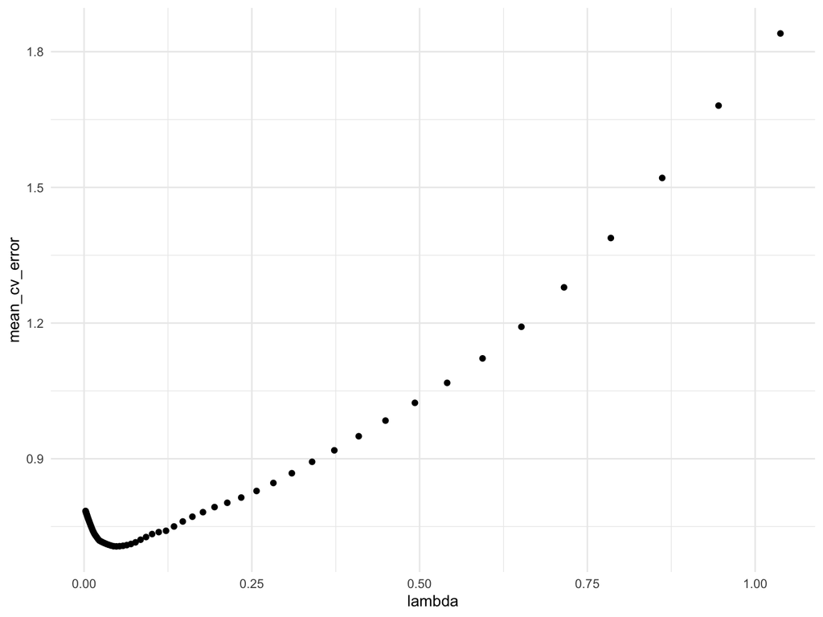

```r
y = data |> pull(life_exp)

x = data |> select(-life_exp) |>as.matrix()

# find optimal lambda value

cv_model = cv.glmnet(x, y, alpha = 1)

best_lambda = cv_model$lambda.min

# plot the CV results
  tibble(lambda = cv_model$lambda,
         mean_cv_error = cv_model$cvm) |>
    ggplot(aes(x = lambda, y = mean_cv_error)) +
    geom_point()
```

```r
# create best model with best lambda

fit.lasso = glmnet(x, y, alpha = 1, lambda = best_lambda)
coef(fit.lasso)
```

```
8 x 1 sparse Matrix of class "dgCMatrix"
                       s0
(Intercept)  7.094740e+01
population   3.800956e-05
income       .
illiteracy   .
murder      -2.727529e-01
hs_grad      4.144960e-02
frost       -4.012398e-03
area         .
```

## F. Comparing subsets and final model.

```r
# refit linear model with top parameters
fit.best = lm(life_exp ~ log(population) + murder + hs_grad +
    frost, data = data)
summary(fit.best)
```

```
Call:
lm(formula = life_exp ~ log(population) + murder + hs_grad +
    frost, data = data)

Residuals:
     Min       1Q   Median       3Q      Max
-1.41760 -0.43880  0.02539  0.52066  1.63048

Coefficients:
                 Estimate Std. Error t value Pr(>|t|)
(Intercept)     68.720810   1.416828  48.503  < 2e-16 ***
log(population)  0.246836   0.112539   2.193 0.033491 *
murder          -0.290016   0.035440  -8.183 1.87e-10 ***
hs_grad          0.054550   0.014758   3.696 0.000591 ***
frost           -0.005174   0.002482  -2.085 0.042779 *
---
Signif. codes:  0 '***' 0.001 '**' 0.01 '*' 0.05 '.' 0.1 ' ' 1

Residual standard error: 0.7137 on 45 degrees of freedom
Multiple R-squared:  0.7404,    Adjusted R-squared:  0.7173
F-statistic: 32.09 on 4 and 45 DF,  p-value: 1.17e-12
```

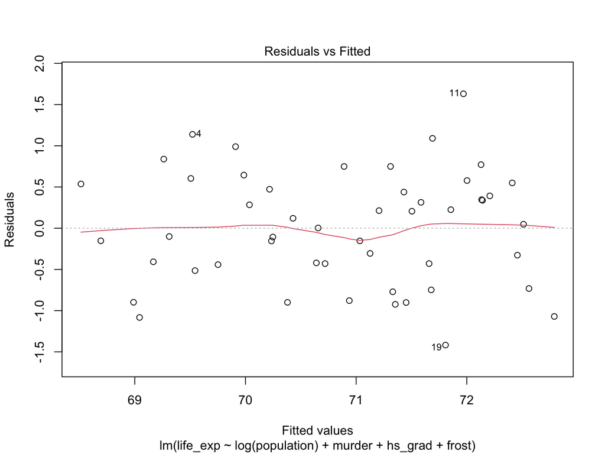

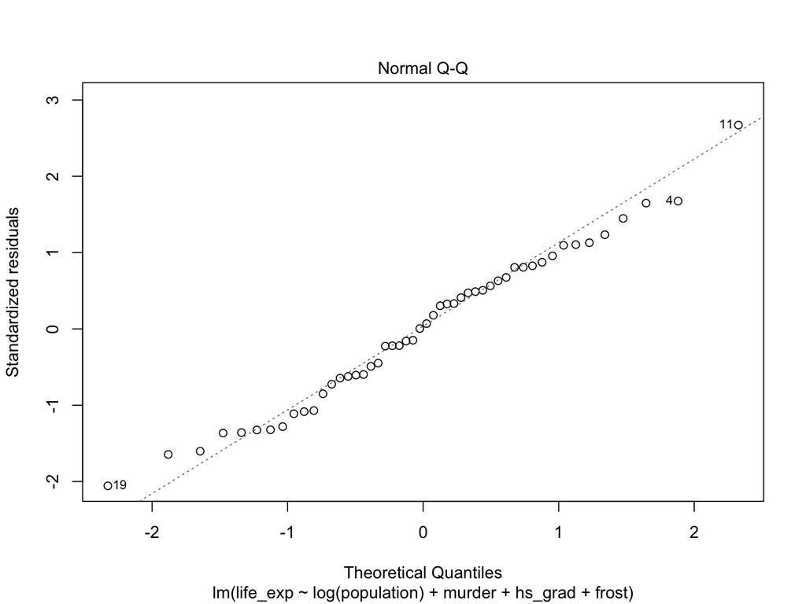

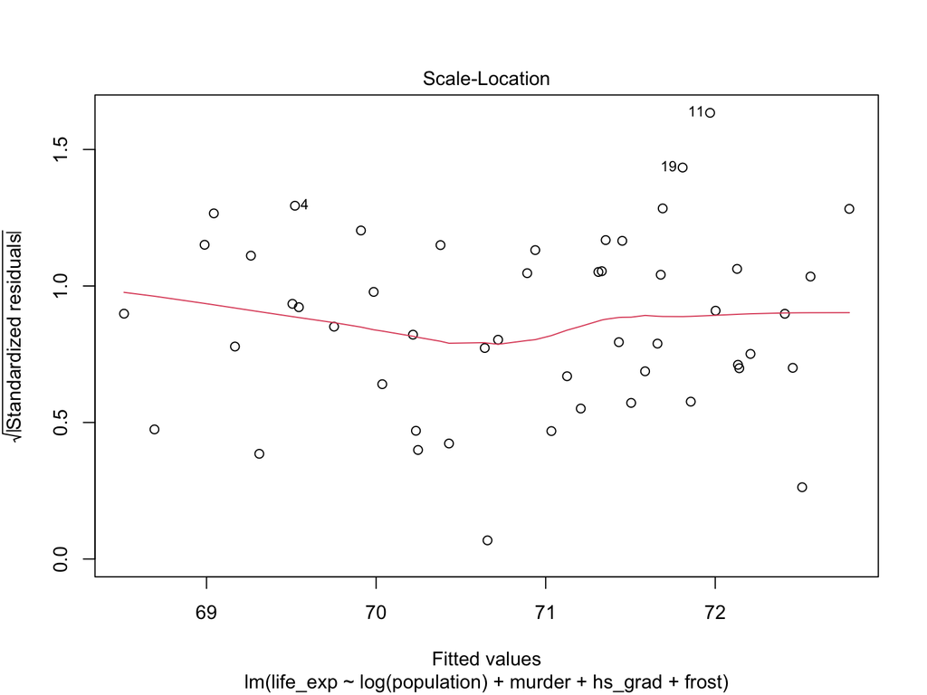

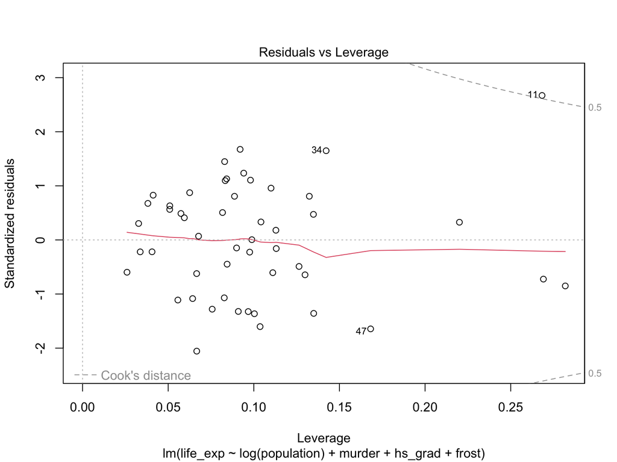

```r
plot(fit.best)
```

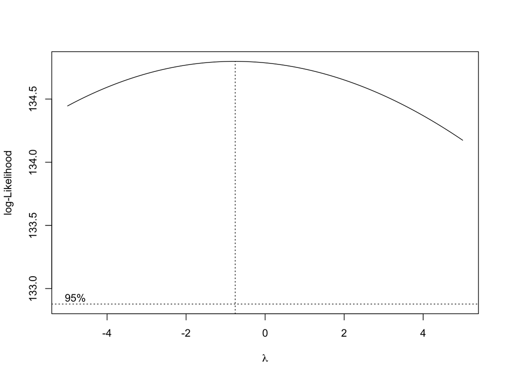

```r
# do boxcox transformation to see if there is a better fit
MASS::boxcox(fit.best, lambda = seq(-5, 5, by = 0.25))
```